# Trabajo de Practicas

Maria Bobes Villa

11/3/2022

# Relacion entre diferentes parametros y el vertido de residuos dentro de las distintas demarcaciones hidrograficas

## 1. Problema ambiental

El volumen de aguas residuales que se genero en España durante el año 2020 fue de 19.242 hm3. Tomando como analogía el volumen del Mar Menor, serian necesarios unos 33 “Mares Menores” para contener toda esa cantidad de agua residual. El volumen de vertidos varia considerablemente entre unas y otras demarcaciones. La superficie de estas, la población asentada y la actividad industrial presente en esos territorios son factores que influyen en la cantidad de residuos que se vierten en las zonas costeras y de transicion. Con este proyecto se pretende comparar las diferentes Demarcaciones Hidrograficas y saber cual de los parámetros es mas determinante en la cantidad de vertidos de aguas residuales para poder atajar de la forma más adecuada el problema de la contaminacion en las zonas costeras y de transicion.

## 2. Objetivos

Este trabajo presenta dos objetivos claros para intentar buscar el origen de la alta produccion de aguas residuales en España:

- Comparar las DDHH para saber cual de ellas produce mas vertidos.
- Ver cual es el parametro (area, poblacion o industrias) mas determinante a la hora de los vertidos.

## 3. Fuentes de datos

Para realizar este trabajo se usaron fundamentalmente informes y datos del Miniaterio para la Transicion Ecologica y el Reto Demografico de España.

Informacion correspondiente a la Demarcacion Hidrografica del Cantabrico Occidental: https://www.miteco.gob.es/es/agua/temas/planificacion-hidrologica/04-coc_2020_vf_tcm30-481567.pdf

Informacion correspondiente a la Demarcacion Hidrografica del Cantabrico Oriental: https://www.miteco.gob.es/fr/agua/temas/planificacion-hidrologica/03-cor_2020_vf_tcm36-481566.pdf

Informacion correspondiente a la Demarcacion Hidrografica de Ceuta: https://www.miteco.gob.es/es/agua/temas/planificacion-hidrologica/24-ceu_2020_vf_tcm30-481583.pdf

Informacion correspondiente al Distrito de la Cuenca Fluvial de Catalunya: https://www.miteco.gob.es/es/agua/temas/planificacion-hidrologica/15-cat_2020_vf_tcm30-481574.pdf

Informacion correspondiente a la Demarcacion Hidrografica de las Cuencas Mediterraneas Andaluzas: https://www.miteco.gob.es/es/agua/temas/planificacion-hidrologica/09-cma_2020_vf_tcm30-481594.pdf

Informacion correspondiente a la Demarcacion Hidrografica del Duero: https://www.miteco.gob.es/es/agua/temas/planificacion-hidrologica/05-due_2020_vf_tcm30-481568.pdf

Informacion correspondiente a la Demarcacion Hidrografica del Ebro: https://www.miteco.gob.es/es/agua/temas/planificacion-hidrologica/14-ebr_2020_vf_tcm30-481573.pdf

Informacion correspondiente a la Demarcacion Hidrografica de Galicia Costa: https://www.miteco.gob.es/es/agua/temas/planificacion-hidrologica/02-gal_2020_vf_tcm30-481565.pdf

Informacion correspondiente a la Demarcacion Hidrografica de Gran Canaria: https://www.miteco.gob.es/es/agua/temas/planificacion-hidrologica/17-gca_2020_vf_tcm30-481576.pdf

Informacion correspondiente a la Demarcacion Hidrografica del Guadalete y Barbate: https://www.miteco.gob.es/es/agua/temas/planificacion-hidrologica/10-gyb_2020_vf_tcm30-481595.pdf

Informacion correspondiente a la Demarcacion Hidrografica del Guadalquivir: https://www.miteco.gob.es/es/agua/temas/planificacion-hidrologica/08-gdq_2020_vf_tcm30-481571.pdf

Informacion correspondiente a la Demarcacion Hidrografica del Guadiana: https://www.miteco.gob.es/es/agua/temas/planificacion-hidrologica/07-gdn_2020_vf_tcm30-481570.pdf

Informacion correspondiente a la Demarcacion Hidrografica de las Illes Balears: https://www.miteco.gob.es/eu/agua/temas/planificacion-hidrologica/16-bal_2020_vf_tcm35-481575.pdf

Informacion correspondiente a la Demarcacion Hidrografica del Jucar: https://www.miteco.gob.es/es/agua/temas/planificacion-hidrologica/13-juc_2020_vf_tcm30-481597.pdf

Informacion correspondiente a la Demarcacion Hidrografica de Melilla: https://www.miteco.gob.es/es/agua/temas/planificacion-hidrologica/25-mel_2020_vf_tcm30-481584.pdf

Informacion correspondiente a la Demarcacion Hidrografica del Mino-Sil: https://www.miteco.gob.es/es/agua/temas/planificacion-hidrologica/01-min_2020_vf_tcm30-481564.pdf

Informacion correspondiente a la Demarcacion Hidrografica del Segura: https://www.miteco.gob.es/es/agua/temas/planificacion-hidrologica/12-seg_2020_vf_tcm30-481572.pdf

Informacion correspondiente a la Demarcacion Hidrografica del Tajo: https://www.miteco.gob.es/es/agua/temas/planificacion-hidrologica/06-taj_2020_vf_tcm30-481569.pdf

Informacion correspondiente a la Demarcacion Hidrografica de Tenerife: https://www.miteco.gob.es/es/agua/temas/planificacion-hidrologica/20-ten_2020_vf_tcm30-481579.pdf

Informacion correspondiente a la Demarcacion Hidrografica del Tinto, Odiel y Piedras: https://www.miteco.gob.es/es/agua/temas/planificacion-hidrologica/11-top_2020_vf_tcm30-481596.pdf

Informacion correspondiente al Censo Nacional de Vertidos: https://www.miteco.gob.es/es/agua/temas/concesiones-y-autorizaciones/vertidos-de-aguas-residuales/censo-vertidos/

El primer paso fue cargar las tablas con los datos en bruto obtenidos de las fuentes previamente mostradas.

```r
hab_area <- read_delim(here("03-Clean", "Informacion_DDHH.csv")) %>%
  mutate(DDHH = str_trim(DDHH))

vertidos<- read_delim(here("03-Clean", "Vertidos_DDHH.csv"))
#vertidos <- read.csv("03-Clean/Vertidos_DDHH.csv", sep=";",dec="," )
```

Se cargaron dos tablas, una con los datos de vertidos y otra con los datos de superficie y numero de habitantes de cada demarcacion hidrografica correspondientes al año 2021.

Despues se procedio a seleccionar las columnas de interes para el estudio.

```r
vertidos_sel<- vertidos %>%
  select(DDHH, Vertidos_industrial, Volumen_total)

vertidos_sel_fil <- vertidos_sel[-18,]
```

Una vez con los datos seleccionados, se unieron ambas tablas para generar una que contuviera toda la informacion necesaria para relaizar el trabajo.

```r
ddhh_data <- full_join(x = hab_area, y = vertidos_sel_fil, by = "DDHH")
#ddhh_data <- merge(x = hab_area, y = vertidos_sel_fil, by = "DDHH", all = TRUE)
```

## 4. Resultados

Para comenzar a responder a nuestras pregunras, el primer paso fue realizar un grafico en el que se pudiese comparar los vertidos producidos por las diferentes demarcaciones para saber cuales eran las mas contaminantes.

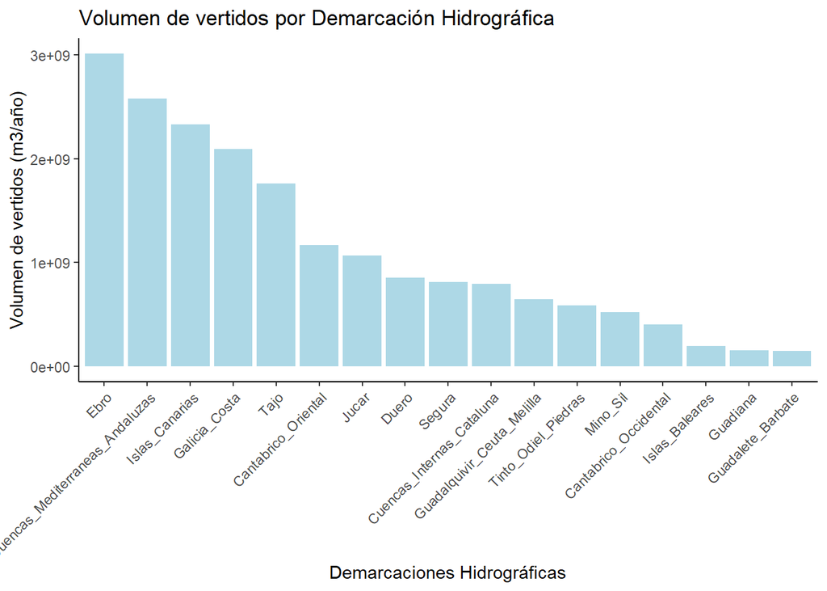

```r
grafica_vertidos_ddhh <- ggplot(data = vertidos_sel_fil, aes(x = reorder(DDHH, -Volumen_total), y = Volumen_total))+
  geom_bar(stat = "identity",
           fill = "lightblue")+
  labs(x = "Demarcaciones Hidrográficas",
       y = "Volumen de vertidos (m3/año)",
       title = "Volumen de vertidos por Demarcación Hidrográfica") +
    theme_classic()+
  theme(axis.text.x = element_text(angle = 45, hjust = 1))

grafica_vertidos_ddhh
```

```r
ggsave(
  plot = grafica_vertidos_ddhh,
  here("04-Figuras", "grafica_vertidos_ddhh.png"),
  width = 20, height = 14)
```

El siguiente paso fue comenzar a relacionar los parametros de interes con las produccion de vertidos para el total de España.

La primera grafica que se realizo fue la que relacionaba el numero de habitantes con el volumen de vetidos.

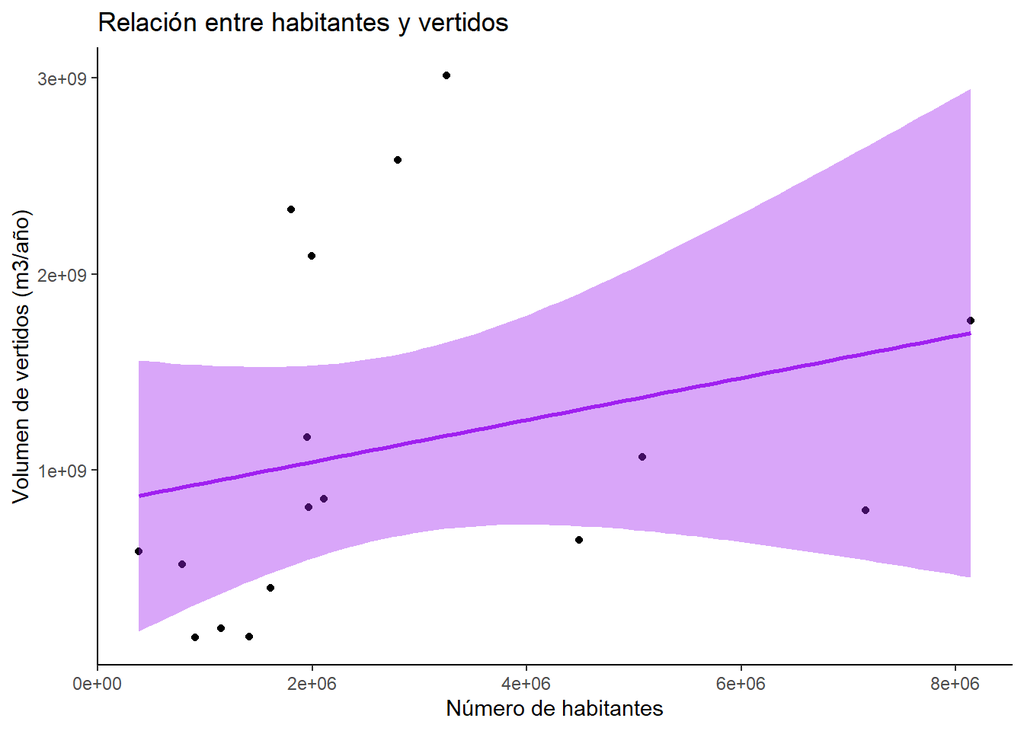

```r
lines_points <- lines+
  geom_point(colors = "black", alpha = 0.5)

grafica_hab_vertidos <- ggplot(data = ddhh_data, aes(x = Habitantes, y = Volumen_total))+
  geom_point()+
  labs(x = "Número de habitantes",
       y = "Volumen de vertidos (m3/año)",
       title = "Relación entre habitantes y vertidos") +
  theme_classic()+
  lines_points+
  geom_smooth(color = "purple",
              fill = "purple",
              method = "lm")

grafica_hab_vertidos
```

```r
ggsave(
  plot = grafica_hab_vertidos,
  here("04-Figuras", "grafica_hab_vertidos.png"),
  width = 20, height = 14)
```

Despues se analizo la relacion del segundo parametro, el area, con la produccion de vertidos.

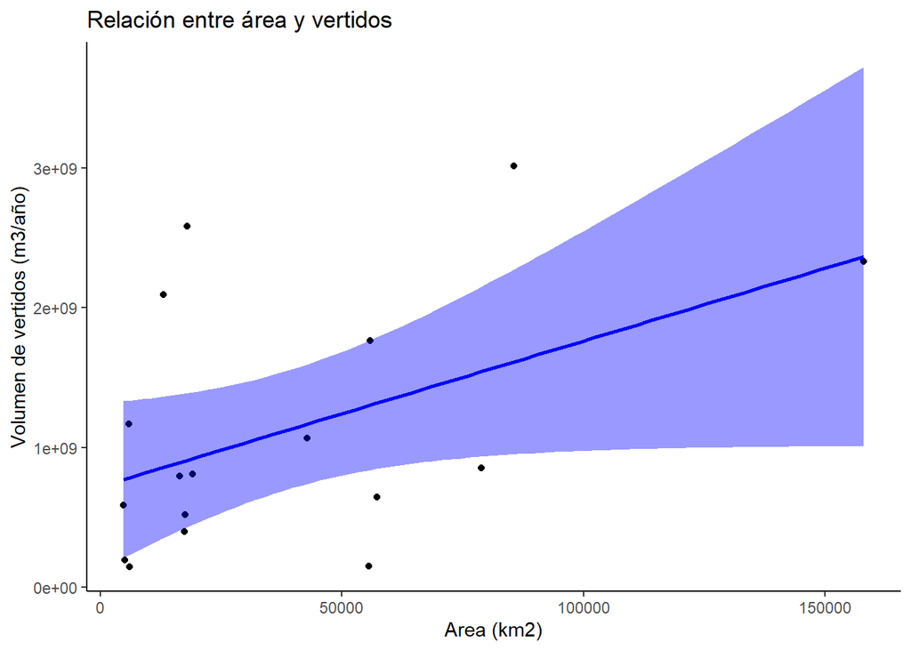

```r
lines_points <- lines+
  geom_point(color = "black", alpha = 0.5)

grafica_area_vertidos <- ggplot(data = ddhh_data, aes(x = Area, y = Volumen_total))+
  geom_point()+
  labs(x = "Area (km2)",
       y = "Volumen de vertidos (m3/año)",
       title = "Relación entre área y vertidos") +
  theme_classic()+
   lines_points+
  geom_smooth(color = "blue",
              fill = "blue",
              method = "lm")

grafica_area_vertidos
```

```r
ggsave(
  plot = grafica_area_vertidos,
  here("04-Figuras", "grafica_area_vertidos.png"),
  width = 20, height = 14)
```

Por ultimo se elaboro la grafica que relacionaba el numero de industrias con la generacion de vertidos.

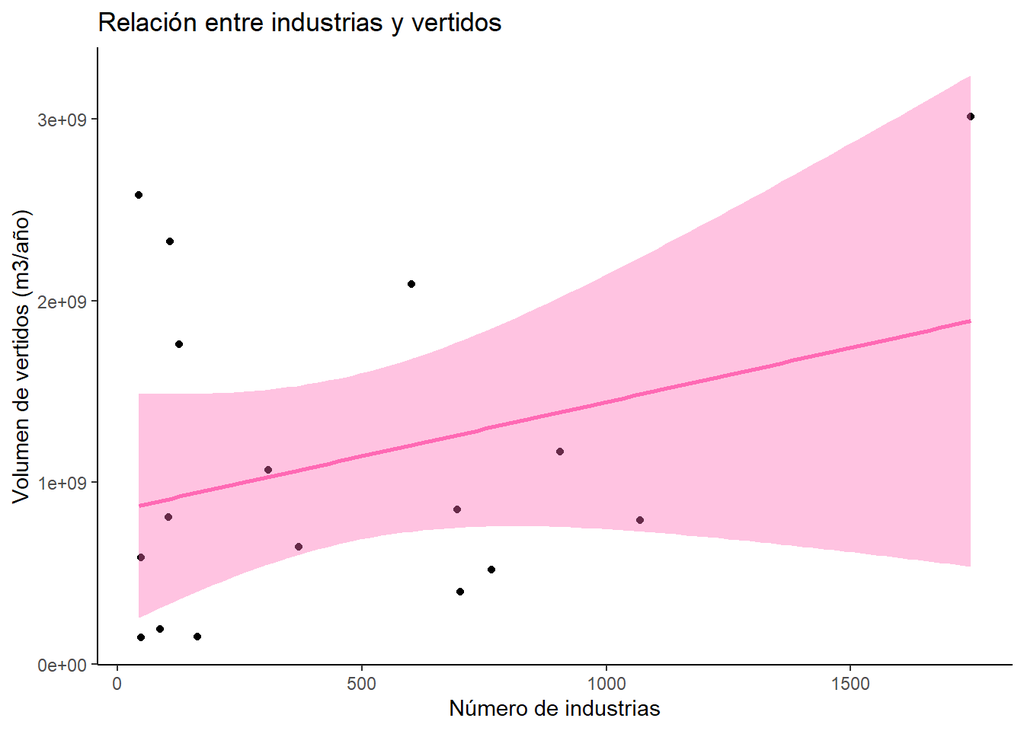

```r
lines_points <- lines+
  geom_point(color = "black", alpha = 0.5)

grafica_indust_vertidos <- ggplot(data = ddhh_data, aes(x = Vertidos_industrial, y = Volumen_total))+
  geom_point()+
  labs(x = "Número de industrias",
       y = "Volumen de vertidos (m3/año)",
       title = "Relación entre industrias y vertidos") +
  theme_classic()+
   lines_points+
  geom_smooth(color = "hotpink",
              fill = "hotpink",
              method = "lm")

grafica_indust_vertidos
```

```r
ggsave(
  plot = grafica_indust_vertidos,
  here("04-Figuras", "grafica_indust_vertidos.png"),
  width = 20, height = 14)
```

Para tener una mejor visualizacion de los datos se procedio a elaborar una grafica resumen que contuviera todas las graficas realizadas hasta el momento.

[figure not shown]

```r
grafica_final <- (grafica_vertidos_ddhh) /
  (grafica_hab_vertidos + grafica_area_vertidos + grafica_indust_vertidos) +
  plot_annotation(
    title = expression(paste("Comparación de los vertidos en las diferentes Demarcaciones Hidrográficas y su relación con diferentes parámetros")),
    caption = "   Fuente de datos:
      - Ministerio para la Transición Ecológica y el Reto Demografico <https://www.miteco.gob.es>.
    Gráficas: Maria Bobes Villa, estudiante de ´Ciencia de Datos Práctica: Resolución de Problemas Ambientales Mediante Proyectos` (Universidad de Alcalá). ",
    theme = theme(
      plot.title = element_text(size = 24, face = "bold"),
      plot.caption = element_text(hjust = 0, size = 14, color = "grey50", margin = margin(t = 25))
      ))

grafica_final
```

```r
ggsave(
  plot = grafica_final,
  here("04-Figuras", "grafica_final.png"),
  width = 20, height = 14)
```

Por ultimo se realizo un mapa interactivo que permite localizar las diferentes demarcaciones, clasificandolas por el volumen de vertidos que generan para observar mejor como se distribuyen en el territorio español, asi como poder ver los diferentes parametros que las caracterizan.

```r
mapacuencas <- esp_get_hydrobasin(domain = "land") %>%
  filter(rotulo != "CEUTA" &
           rotulo != "EL HIERRO" &
           rotulo != "FUERTEVENTURA" &
           rotulo != "GRAN CANARIA" &
           rotulo != "LA GOMERA" &
           rotulo != "LA PALMA" &
           rotulo != "LANZAROTE" &
           rotulo != "LA GOMERA" &
           rotulo != "MELILLA" &
           rotulo != "TENERIFE") %>%
  mutate(rotulo = sort(rotulo)) #sort me ordena caracteres y arrange solo numeros

#view(mapacuencas)

###
geom_mapacuencas <- select (mapacuencas, geom)

#view(geom_mapacuencas)

#geom_ordenado <- geom_mapacuencas %>% arrange (factor(geom = geom[c(2,5,6,12,8,7,16,14,9,11,15,10,3,13,1,4)]))
#geom_ordenado <- geom_mapacuencas [ , c(2,5,6,12,8,7,16,14,9,11,15,10,3,13,1,4)]
#geom_ordenado = subset (geom_mapacuencas, select=c(2,5,6,12,8,7,16,14,9,11,15,10,3,13,1,4))
###

vertidos_sin_canarias <- vertidos_sel_fil[-12,]

ddhh_data_sin_canarias <- ddhh_data [-12,]

volumen_solo <- vertidos_sin_canarias %>%
  dplyr::select(Volumen_total) %>%
  as_vector()

area_solo <- ddhh_data_sin_canarias %>%
  dplyr::select(Area) %>%
  as_vector()

hab_solo <- ddhh_data_sin_canarias %>%
  dplyr::select(Habitantes) %>%
  as_vector()

industrias_solo <- vertidos_sin_canarias %>%
  dplyr::select(Vertidos_industrial) %>%
  as_vector()

mapacuencas_total <- mapacuencas %>%
  mutate(volumen = volumen_solo/1000000) %>%
  mutate(area = area_solo ) %>%
  mutate(habitantes = hab_solo )  %>%
  mutate(industrias = industrias_solo )

#view(mapacuencas_total)

colores <- seq(min(mapacuencas_total$volumen), (max(mapacuencas_total$volumen)+1), length = 11)

paleta <- colorBin(palette="Purples",
                      domain=mapacuencas_total$volumen,
                      bins=colores)
texto <- paste(
  "Vertidos: ", mapacuencas_total$volumen, "<br/>",
  "Habitantes: ", mapacuencas_total$habitantes, "<br/>",
  "Area: ", mapacuencas_total$area, "<br/>",
  "Industrias: ", mapacuencas_total$industrias,
  sep="") %>%
  lapply(htmltools::HTML)

ddhh_data_mapa <- leaflet::leaflet(mapacuencas_total)%>%
  leaflet::addPolygons(color = "#222",
                       weight = 2,
                       opacity = 1,
                       fillColor = ~paleta(mapacuencas_total$volumen),
                       fillOpacity = 0.7,
                       popup = ~volumen,
                       label = texto,
                       labelOptions = labelOptions(style = list("font-weight" = "normal",
                       padding = "3px 8px"),
                       textsize = "13px")) %>%
  addLegend(pal = paleta, values = ~volumen, opacity = 0.9,
title = "Volumen de vertidos (km3/año)")

ddhh_data_mapa
```

[interactive chart not shown]